# **VRCC – main analysis**

Pawel Motyka, Felix Klotzsche, Aleksander Molak pmotyka@psych.pan.pl klotzsche@cbs.mpg.de aleksander.molak@gmail.com

Jan 2024

**List of sections**:

- S1 – Load required packages and data
- S2 – Data checks and descriptive statistics of dep. variables
- S3 – Hypothesis 1: Comparison of distance error between threatening and non-threatening objects
- S4 – Hypothesis 2: Comparison of distance error between cardiac phases
- S5 – Comparison of distance error between cardiac phases (individual animals)
- S6 – Distance errors as a function of true distance (individual animals)
- S7 – Width of distance error distributions as function of threat and cardiac phase

**1. Load required packages and data**

```r
knitr::opts_chunk$set(echo = TRUE)

# define colors:
c_threat <- "#FE5D9F"
c_nonthreat <- "#54426B"
c_neutral <- "#623CEA"
c_systole <- "#F686BD"
c_diastole <- "#F4BBD3"
basic_color <- '#195e8c'


# Utils
library(tidyverse)
library(dplyr)
library(here)
library(tidyr)


# load helper functions
source(here::here("./Code/Analyses/VRTask/Utils/stats_utils.r"))

# Plotting and tables
library(ggplot2)
library(sjPlot)
library(gghalves)
library(ggridges)
library(scales)
library(colorspace)
library(Rmisc)

# Statistical tools
library(lme4)
library(lmtest)
library(lmerTest)
library(car)
library(effsize)
library(psych)
library(equivalence)
library(BayesFactor)
library(circular)
library(afex)

# Set up the fulldata directory
VRCC_dir         <- here::here()

# Read the preprocessed data
data <- read.csv(file = paste0(VRCC_dir,"/Data/VRTask/VRCC_data_consolidated-2023-08-10.csv"))

# conversion of distance from m to cm
data <- data %>%
  mutate(EstimatedDistance = EstimatedDistance * 100,
         RealDistance = RealDistance * 100,
         DistanceError = DistanceError * 100,
         DistanceErrorAbs = DistanceErrorAbs * 100,
         LocalizationError = LocalizationError * 100)
```

**2. Data checks and descriptive statistics**

```r
# --- Control analysis: avg. distance and angular errors different from zero? ---

# Transform angular error from radians to degree:
data$AngularErrorDeg <- data$AngularErrorRad * 180 / pi
data$AngularErrorDegAbs <- abs(data$AngularErrorDeg)

dd <- data %>%
  dplyr::group_by(ID) %>%
  dplyr::summarize(mean_distance = mean(DistanceError),
                   mean_angular = mean(AngularErrorDeg))

# check whether average distance error was different from zero
shapiro.test(dd$mean_distance)
```

```
##
##  Shapiro-Wilk normality test
##
## data:  dd$mean_distance
## W = 0.95708, p-value = 0.1243
```

```r
t.test(dd$mean_distance, mu = 0, alternative = "two.sided")
```

```
##
##  One Sample t-test
##
## data:  dd$mean_distance
## t = -0.058208, df = 40, p-value = 0.9539
## alternative hypothesis: true mean is not equal to 0
## 95 percent confidence interval:
##  -10.055529   9.492535
## sample estimates:
##  mean of x
## -0.2814969
```

```r
describe(dd$mean_distance)
```

```
##    vars  n  mean    sd median trimmed   mad    min   max  range  skew kurtosis
## X1    1 41 -0.28 30.97   1.74    -0.8 23.55 -90.66 75.38 166.04 -0.01     1.09
##      se
## X1 4.84
```

```r
# check whether average angular error was different from zero
shapiro.test(dd$mean_angular)
```

```
##
##  Shapiro-Wilk normality test
##
## data:  dd$mean_angular
## W = 0.97648, p-value = 0.545
```

```r
wilcox.test(dd$mean_angular, mu = 0, alternative = "two.sided")
```

```
##
##  Wilcoxon signed rank exact test
##
## data:  dd$mean_angular
## V = 234, p-value = 0.01003
## alternative hypothesis: true location is not equal to 0
```

```r
t.test(dd$mean_angular, mu = 0, alternative = "two.sided")
```

```
##
##  One Sample t-test
##
## data:  dd$mean_angular
## t = -2.8134, df = 40, p-value = 0.007564
## alternative hypothesis: true mean is not equal to 0
## 95 percent confidence interval:
##  -0.5553504 -0.0910192
## sample estimates:
##  mean of x
## -0.3231848
```

```r
describe(dd$mean_angular)
```

```
##    vars  n  mean   sd median trimmed  mad   min  max range  skew kurtosis   se
## X1    1 41 -0.32 0.74  -0.19    -0.3 0.62 -2.57 1.26  3.83 -0.49     0.63 0.11
```

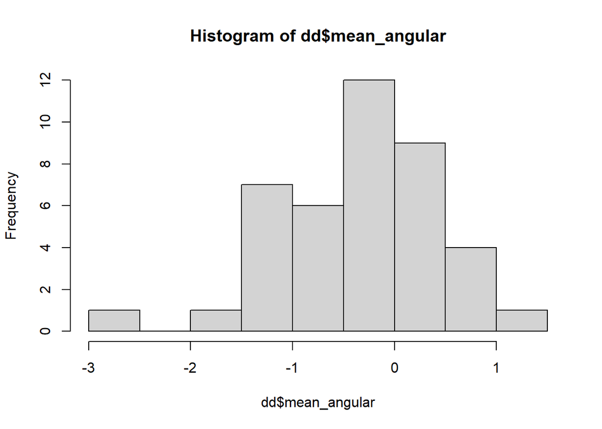

```r
hist(dd$mean_angular)
```

```r
# wilcox & t test largely agree (not surprising due to reasonable sample size; for sake of simplicity we can therefore just report the t test)
```

**3. Hypothesis 1: Comparison of distance error between threatening and non-threatening objects**

```r
# 3.1. Preregistered analysis: compare distance error between threat and non-threat

d <- data %>%
  dplyr::group_by(ID) %>%
  dplyr::summarize(mean_threat = mean(DistanceError[FearObject == "True"]),
                   mean_nonthreat = mean(DistanceError[FearObject == "False"]),
                   sd_threat = sd(DistanceError[FearObject == "True"]),
                   sd_nonthreat = sd(DistanceError[FearObject == "False"]))

# check normality of distributions
shapiro.test(d$mean_threat)
```

```
##
##  Shapiro-Wilk normality test
##
## data:  d$mean_threat
## W = 0.96074, p-value = 0.1669
```

```r
shapiro.test(d$mean_nonthreat)
```

```
##
##  Shapiro-Wilk normality test
##
## data:  d$mean_nonthreat
## W = 0.95537, p-value = 0.1082
```

```r
# perform paired t-test
t.test(d$mean_threat, d$mean_nonthreat, alt = "two.sided", conf = 0.95, paired = T)
```

```
##
##  Paired t-test
##
## data:  d$mean_threat and d$mean_nonthreat
## t = 3.3386, df = 40, p-value = 0.00183
## alternative hypothesis: true difference in means is not equal to 0
## 95 percent confidence interval:
##  0.8358152 3.4000347
## sample estimates:
## mean of the differences
##                2.117925
```

```r
# calculate Cohen's d
effsize::cohen.d(d$mean_threat, d$mean_nonthreat, paired = T)
```

```
##
## Cohen's d
##
## d estimate: 0.06724989 (negligible)
## 95 percent confidence interval:
##      lower      upper
## 0.02711879 0.10738099
```

```r
# show summary statistics
describe(d$mean_threat)
```

```
##    vars  n mean    sd median trimmed   mad   min   max  range  skew kurtosis
## X1    1 41 0.78 30.68   1.41    0.38 22.36 -90.4 76.71 167.11 -0.04     1.13
##      se
## X1 4.79
```

```r
describe(d$mean_nonthreat)
```

```
##    vars  n  mean    sd median trimmed   mad    min   max  range skew kurtosis
## X1    1 41 -1.34 31.38   0.28   -1.97 22.02 -90.93 74.05 164.98 0.02     1.03
##     se
## X1 4.9
```

```r
## Compare the precision (SD) between threatening and non-threatening animals
# check normality of distributions
shapiro.test(d$sd_threat)
```

```
##
##  Shapiro-Wilk normality test
##
## data:  d$sd_threat
## W = 0.82258, p-value = 1.697e-05
```

```r
shapiro.test(d$sd_nonthreat)
```

```
##
##  Shapiro-Wilk normality test
##
## data:  d$sd_nonthreat
## W = 0.75929, p-value = 8.418e-07
```

```r
# perform paired t-test
t.test(d$sd_threat, d$sd_nonthreat, alt = "two.sided", conf = 0.95, paired = T)
```

```
##
##  Paired t-test
##
## data:  d$sd_threat and d$sd_nonthreat
## t = 3.2257, df = 40, p-value = 0.002506
## alternative hypothesis: true difference in means is not equal to 0
## 95 percent confidence interval:
##  0.9996733 4.3539903
## sample estimates:
## mean of the differences
##                2.676832
```

```r
# calculate Cohen's d
effsize::cohen.d(d$sd_threat, d$sd_nonthreat, paired = T)
```

```
##
## Cohen's d
##
## d estimate: 0.2289945 (small)
## 95 percent confidence interval:
##      lower      upper
## 0.08588034 0.37210857
```

```r
# show summary statistics
describe(d$sd_threat)
```

```
##    vars  n  mean    sd median trimmed  mad   min   max range skew kurtosis   se
## X1    1 41 43.26 11.98  40.65   41.59 7.86 28.01 87.62 59.61 1.85     4.13 1.87
```

```r
describe(d$sd_nonthreat)
```

```
##    vars  n  mean    sd median trimmed  mad  min   max range skew kurtosis   se
## X1    1 41 40.58 11.08  39.38   39.09 7.66 27.2 92.37 65.17 2.59     9.41 1.73
```

```r
# for how many subjects threatening animals were perceived as closer than non-threatening ones
d$diff_distances <- d$mean_nonthreat - d$mean_threat
length(d$diff_distances[d$diff_distances > 0])
```

```
## [1] 14
```

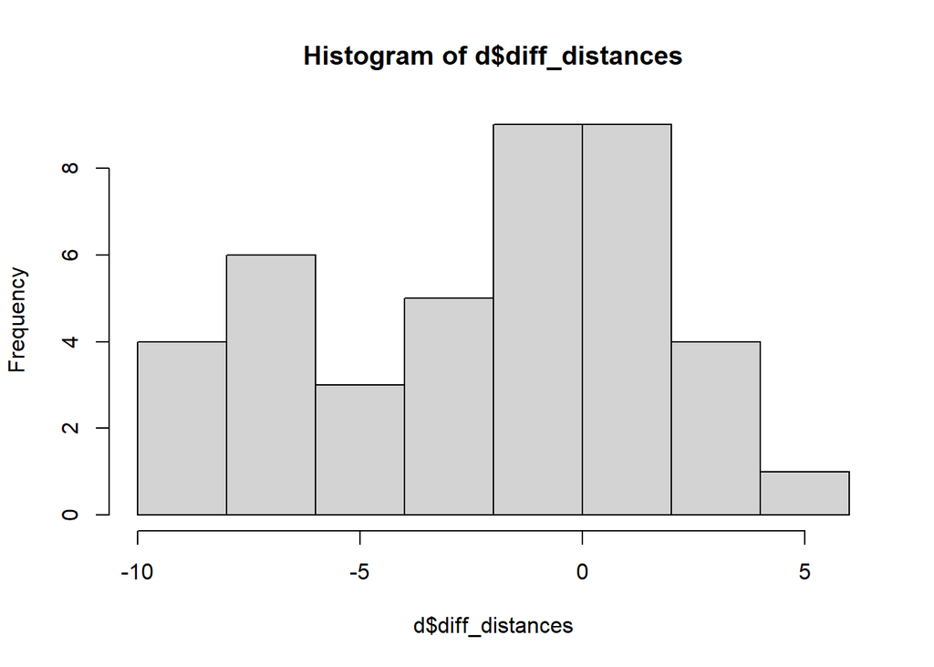

```r
hist(d$diff_distances)
```

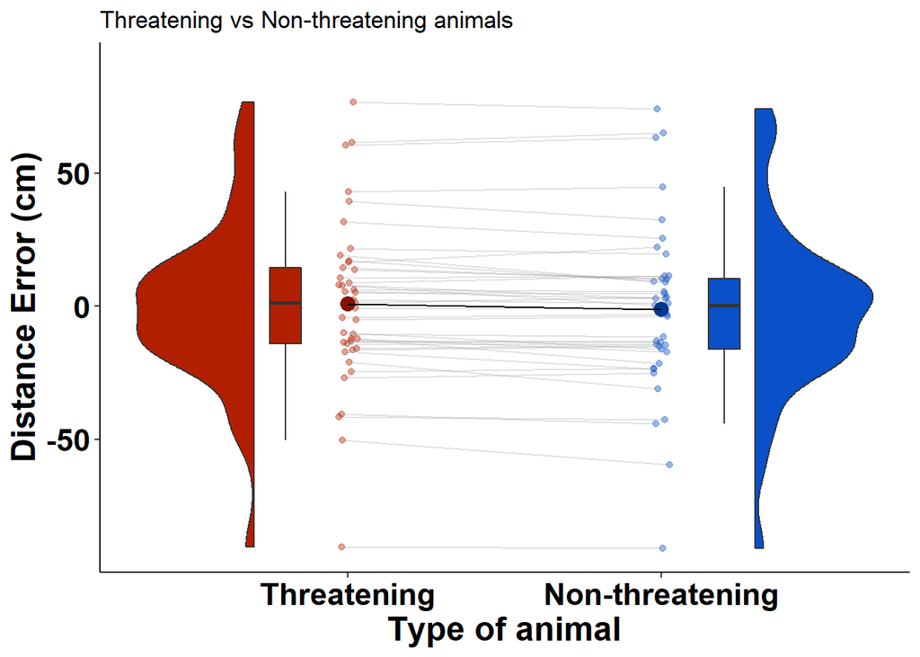

```r
# 3.2. Plot results - hypothesis 1

# specify colors
cR <- rgb(178/255, 31/255, 0/255)    # altern.: c_threat         # Old value: rgb(178/255, 31/255, 0/255)
cB <- rgb(10/255, 80/255, 200/255)   # altern.: c_nonthreat      # Old value:  rgb(10/255, 80/255, 200/255)

# prepare data

d <- data %>%
  dplyr::group_by(ID) %>%
  dplyr::summarize(mean_threat = mean(DistanceError[FearObject == "True"]),
                   mean_non_threat = mean(DistanceError[FearObject == "False"]))
d <- gather(d, threat, distance_error, mean_threat:mean_non_threat)
d$threat_f[d$threat == "mean_threat"] <- 1
d$threat_f[d$threat == "mean_non_threat"] <- 2
d$pos <- jitter(d$threat_f, amount=.03)
m_threat <- mean(d$distance_error[d$threat == "mean_threat"])
m_nonthreat <- mean(d$distance_error[d$threat == "mean_non_threat"])

# get standard deviations
score_sd_2 <- sd(d$distance_error[d$threat == "mean_non_threat"])
score_sd_1 <- sd(d$distance_error[d$threat == "mean_threat"])

# get standard errors
score_se_2 <- score_sd_2/sqrt(length(unique(d$ID)))
score_se_1 <- score_sd_1/sqrt(length(unique(d$ID)))

# get confidence intervals (95%)
score_ci_2 <- CI(d$distance_error[d$threat == "mean_non_threat"], ci = 0.95)
score_ci_1 <- CI(d$distance_error[d$threat == "mean_threat"], ci = 0.95)
ci <- c((score_ci_1[1] - score_ci_1[3]), (score_ci_2[1] - score_ci_2[3]))

# create ggplot
f1 <- ggplot(data = d, aes(y = distance_error)) +

  #Add geom_() objects
  geom_point(data = d %>% filter(threat_f =="1"),
             aes(x = pos),
             color = cR,
             size = 1.5,
             alpha = .4) +

  geom_point(data = d %>% filter(threat_f =="2"),
             aes(x = pos),
             color = cB,
             size = 1.5,
             alpha = .4) +

  geom_line(aes(x = pos, group = ID),
            color = 'gray60',
            alpha = .3) +

  geom_half_boxplot(
    data = d %>% filter(threat_f=="1"),
    aes(x=threat_f, y = distance_error),
    position = position_nudge(x = -.25),
    side = "r",
    outlier.shape = NA,
    center = TRUE,
    errorbar.draw = FALSE,
    width = .2,
    fill = cR) +

  geom_half_boxplot(
    data = d %>% filter(threat_f=="2"),
    aes(x=threat_f, y = distance_error),
    position = position_nudge(x = .15),
    side = "r",
    outlier.shape = NA,
    center = TRUE,
    errorbar.draw = FALSE,
    width = .2,
    fill = cB) +

  geom_half_violin(
    data = d %>% filter(threat_f=="1"),
    aes(x = threat_f, y = distance_error),
    position = position_nudge(x = -.3),
    side = "l", fill = cR) +

  geom_half_violin(
    data = d %>% filter(threat_f=="2"),
    aes(x = threat_f, y = distance_error),
    position = position_nudge(x= .3),
    side = "r",
    fill = cB) +

  geom_point(data = d %>% filter(threat_f=="1") %>%
                          filter(row_number() == 1),
            aes(x = threat_f, y = m_threat),
            position = position_nudge(x = .0),
            color = darken(cR,0.3),
            size = 5.5,
            shape = 20) +

  geom_point(data = d %>% filter(threat_f=="2") %>%
                          filter(row_number() == 1),
            aes(x = threat_f, y = m_nonthreat),
            position = position_nudge(x = -.0),
            color = darken(cB, 0.3),
            size = 5.5,
            shape = 20) +
  geom_line(data = tibble(x = c(1,2),
                         y = c(m_threat, m_nonthreat)),
           aes(x = x, y = y)) +

  scale_x_continuous(breaks=c(1,2),
                     labels=c("Threatening", "Non-threatening")) +
  xlab("Type of animal") +
  ylab("Distance Error (cm)") +
  ggtitle('Threatening vs Non-threatening animals') +
  theme_classic()+
  coord_cartesian(ylim=c(min(d$distance_error), 90)) +
  theme(panel.grid.major = element_blank(),
        panel.grid.minor = element_blank(),
        panel.background = element_blank(),
        axis.line = element_line(colour = "black"),
        axis.title = element_text(face="bold",
                                  size=18.5,
                                  colour = "black"),
        axis.text = element_text(face="bold",
                                 size=17,
                                 colour = "black"))

f1
```

```r
# save to disc:
fpath_figs <- file.path(VRCC_dir, 'Code', 'Analyses', 'VRTask', 'Figures')
fname <- file.path(fpath_figs, 'VRCC_DistErr_BoxViolin.pdf')
pdf(fname)
f1
dev.off()
```

```r
# Plot results for single animals

# Overview box plot:
d <- data %>%
  dplyr::group_by(ID, Stimulus) %>%
  dplyr::summarize(distance_error = mean(DistanceError))
```

```
## argument.
```

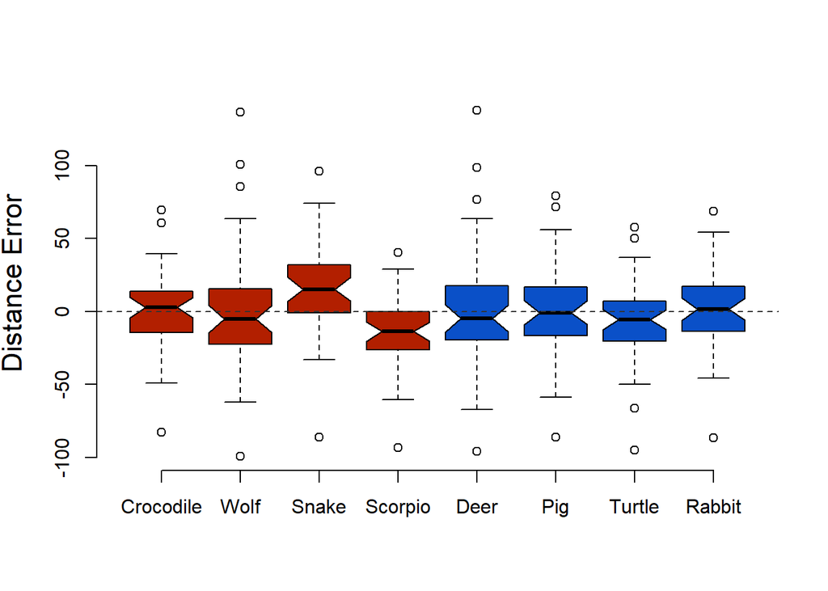

```r
d <- spread(d, key = Stimulus, value = distance_error)

boxplot(d$Crocodile, d$FinalWolf, d$FinalSnake, d$Scorpio, d$Deer, d$Pig,  d$Turtle, d$Rabbit,
        col = c(cR, cR, cR, cR, cB, cB, cB,cB),
        names = c("Crocodile", "Wolf", "Snake", "Scorpio", "Deer", "Pig", "Turtle", "Rabbit"),
        frame = FALSE,
        notch = TRUE,
        ylab = "Distance Error",
        cex.lab = 1.4,
        cex.axis = 1)
abline(h=0, col="gray20", lwd = 1.3, lty = 2)
```

```r
# pub-ready density plot:
data_avg <- data %>%
  group_by(Stimulus, ID) %>%
  dplyr::summarize(DistanceError = mean(DistanceError),
                   FearObject = first(FearObject)) %>%
  mutate(Stimulus = revalue(Stimulus, c('FinalWolf'='Wolf',
                                        'FinalSnake' = 'Snake',
                                        'Scorpio' = 'Scorpion'))) %>%
  ungroup()
```

```
## argument.
```

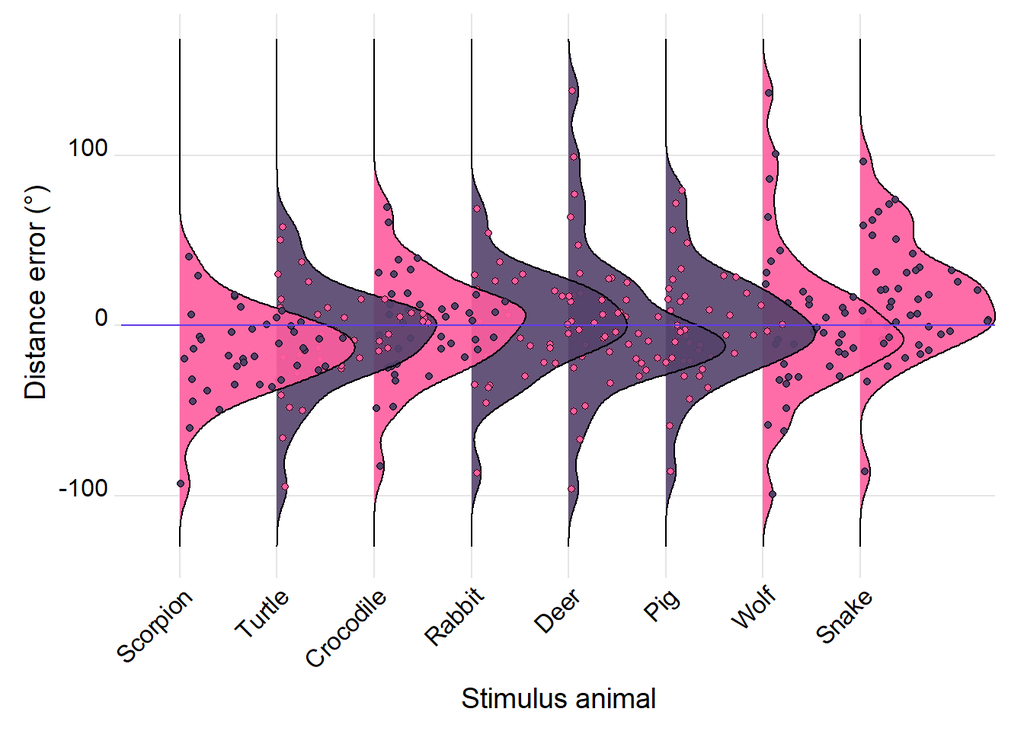

```r
ggplot(data_avg, aes(x = DistanceError,
                     y = fct_reorder(Stimulus, .x = DistanceError, .fun=mean),
                     fill = FearObject)) +
  geom_density_ridges(aes(point_fill = factor(FearObject),
                          point_color= factor(FearObject)),
                      alpha = 0.9,
                      jittered_points = TRUE,
                      point_alpha=1,
                      point_shape=21,
                      stat = "density_ridges") +
  theme_ridges() +
  theme(legend.position = "none",
        axis.text.x = element_text(angle = 45, hjust = 1),
        axis.title.x = element_text(hjust = 0.5),  # Center x-axis label
        axis.title.y = element_text(hjust = 0.5)) +
  geom_vline(xintercept = 0, color = c_neutral) +
  scale_fill_manual(values = c(c_nonthreat, c_threat)) +
  scale_discrete_manual(aesthetics = "point_color", values = c("black", "black")) +
  scale_discrete_manual(aesthetics = "point_fill", values = c(c_threat, c_nonthreat)) +
  ylab("Stimulus animal") +
  xlab("Distance error (°)") +
  coord_flip() -> plt

plt
```

```r
# save to disc:
fpath_figs <- file.path(VRCC_dir, 'Code', 'Analyses', 'VRTask', 'Figures')
fname <- file.path(fpath_figs, 'VRCC_DistErr_RidgeDensity.pdf')
pdf(fname)
plt
dev.off()
```

**Exploratory/control analysis: compare angular error between threat and non-threat**

```r
# 3.3 Exploratory/control analysis: compare angular error between threat and non-threat
d <- data %>%
  dplyr::group_by(ID) %>%
  dplyr::summarize(mean_threat = mean(AngularErrorDeg[FearObject == "True"]),
                   mean_non_threat = mean(AngularErrorDeg[FearObject == "False"]))

# check normality of distributions
shapiro.test(d$mean_threat)
```

```
##
##  Shapiro-Wilk normality test
##
## data:  d$mean_threat
## W = 0.97825, p-value = 0.6095
```

```r
shapiro.test(d$mean_non_threat)
```

```
##
##  Shapiro-Wilk normality test
##
## data:  d$mean_non_threat
## W = 0.97451, p-value = 0.4775
```

```r
# perform paired t-test
t.test(d$mean_threat, d$mean_non_threat, alt = "two.sided", conf = 0.95, paired = T)
```

```
##
##  Paired t-test
##
## data:  d$mean_threat and d$mean_non_threat
## t = 22.185, df = 40, p-value < 2.2e-16
## alternative hypothesis: true difference in means is not equal to 0
## 95 percent confidence interval:
##  0.4729594 0.5677702
## sample estimates:
## mean of the differences
##               0.5203648
```

```r
# calculate Cohen's d
effsize::cohen.d(d$mean_threat, d$mean_non_threat, paired = T)
```

```
##
## Cohen's d
##
## d estimate: 0.6915944 (medium)
## 95 percent confidence interval:
##     lower     upper
## 0.6225358 0.7606530
```

```r
# show summary statistics
describe(d$mean_threat)
```

```
##    vars  n  mean   sd median trimmed  mad   min  max range  skew kurtosis   se
## X1    1 41 -0.06 0.73   0.06   -0.04 0.58 -2.18 1.54  3.71 -0.45     0.42 0.11
```

```r
describe(d$mean_non_threat)
```

```
##    vars  n  mean   sd median trimmed  mad   min  max range  skew kurtosis   se
## X1    1 41 -0.58 0.75  -0.46   -0.56 0.66 -2.96 0.99  3.95 -0.55     0.82 0.12
```

```r
d <- data %>%
  dplyr::group_by(ID, FearObject) %>%
  dplyr::summarize(mean_AngErr = mean(AngularErrorDeg),
                   mean_DistErr = mean(DistanceError),
                   sd_AngErr = sd(AngularErrorDeg),
                   sd_DistErr = sd(DistanceError),
      ) %>%
  ungroup()
```

```
## argument.
```

```r
# check normality of distributions
shapiro.test(d$sd_AngErr[d$FearObject=="True"])
```

```
##
##  Shapiro-Wilk normality test
##
## data:  d$sd_AngErr[d$FearObject == "True"]
## W = 0.98495, p-value = 0.8541
```

```r
shapiro.test(d$sd_AngErr[d$FearObject=="False"])
```

```
##
##  Shapiro-Wilk normality test
##
## data:  d$sd_AngErr[d$FearObject == "False"]
## W = 0.97499, p-value = 0.4938
```

```r
t.test(d$sd_AngErr[d$FearObject=="True"], d$sd_AngErr[d$FearObject=="False"], paired = TRUE, alternative = "two.sided")
```

```
##
##  Paired t-test
##
## data:  d$sd_AngErr[d$FearObject == "True"] and d$sd_AngErr[d$FearObject == "False"]
## t = 4.1916, df = 40, p-value = 0.0001487
## alternative hypothesis: true difference in means is not equal to 0
## 95 percent confidence interval:
##  0.07474886 0.21395608
## sample estimates:
## mean of the differences
##               0.1443525
```

```r
# Show means:
d %>% group_by(FearObject) %>%
  dplyr::summarise(gmean_AngErrDeg = mean(mean_AngErr),
                   gmean_DistErr = mean(mean_DistErr),
                   meansd_AngErrDeg = mean(sd_AngErr),
                   meansd_DistErr = mean(sd_DistErr)
                   ) -> summary_AngDistErr

print(summary_AngDistErr)
```

```
## # A tibble: 2 x 5
##   FearObject gmean_AngErrDeg gmean_DistErr meansd_AngErrDeg meansd_DistErr
##   <chr>                <dbl>         <dbl>            <dbl>          <dbl>
## 1 False              -0.583         -1.34              2.03           40.6
## 2 True               -0.0630         0.779             2.17           43.3
```

```r
###3.3 Plot results for different animals
d <- data %>%
  dplyr::group_by(ID, Stimulus) %>%
  dplyr::summarize(angular_error = mean(AngularErrorDeg))
```

```
## argument.
```

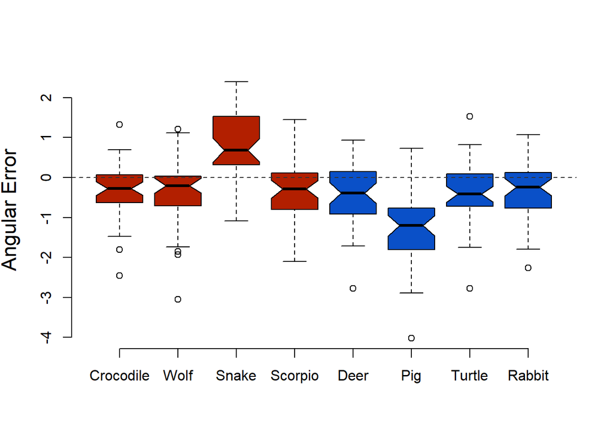

```r
d <- spread(d, key = Stimulus, value = angular_error)

boxplot(d$Crocodile, d$FinalWolf, d$FinalSnake, d$Scorpio, d$Deer, d$Pig,  d$Turtle, d$Rabbit,
        col = c(cR, cR, cR, cR, cB, cB, cB,cB),
        names = c("Crocodile", "Wolf", "Snake", "Scorpio", "Deer", "Pig", "Turtle", "Rabbit"),
        frame = FALSE,
        notch = TRUE,
        ylab = "Angular Error",
        cex.lab = 1.4,
        cex.axis = 1)
abline(h=0, col="gray20", lwd = 1.3, lty = 2)
```

**4. Hypothesis 2: Comparison of distance error between cardiac phases**

*Binary comparison: ANOVA*

```r
# 4.1. 2 x 2 ANOVA analysis (with Bonferroni post hoc comparisons)

# prepare data
d <- data[data$c_phase == "systole" | data$c_phase == "diastole",]
d <- dplyr::select(d, ID, DistanceError, c_phase, FearObject)
d <- d %>%
  dplyr::group_by(ID, c_phase, FearObject) %>%
  dplyr::summarize(DistanceError = mean(DistanceError))
# run analysis
fit_all <- aov_ez(data = d,
                  dv = "DistanceError",
                  id = "ID",
                  within=c("c_phase", "FearObject"),
                  return = afex_options("return_aov"),
                  anova_table = list(),
                  fun_aggregate = mean)
fit_all
```

```
## Anova Table (Type 3 tests)
##
## Response: DistanceError
##               Effect    df   MSE       F   ges p.value
## 1            c_phase 1, 40 13.46    0.11 <.001    .746
## 2         FearObject 1, 40 21.71 7.87 **  .001    .008
## 3 c_phase:FearObject 1, 40 17.23    0.94 <.001    .337
## ---
## Signif. codes:  0 '***' 0.001 '**' 0.01 '*' 0.05 '+' 0.1 ' ' 1
```

```r
summary(fit_all) # see epsilon values
```

```
##
## Univariate Type III Repeated-Measures ANOVA Assuming Sphericity
##
##                     Sum Sq num Df Error SS den Df F value   Pr(>F)
## (Intercept)          9.906      1   156776     40  0.0025 0.960155
## c_phase              1.433      1      539     40  0.1065 0.745912
## FearObject         170.960      1      868     40  7.8743 0.007708 **
## c_phase:FearObject  16.257      1      689     40  0.9435 0.337210
## ---
## Signif. codes:  0 '***' 0.001 '**' 0.01 '*' 0.05 '.' 0.1 ' ' 1
```

```r
# post-hoc comparisons (Bonferroni correction)
ref <- emmeans::emmeans(fit_all, specs = c("c_phase", "FearObject"))
ref
```

```
##  c_phase  FearObject emmean   SE df lower.CL upper.CL
##  diastole False      -0.858 5.02 40   -11.00     9.28
##  systole  False      -1.675 5.01 40   -11.81     8.46
##  diastole True        0.554 4.84 40    -9.23    10.33
##  systole  True        0.997 4.81 40    -8.73    10.72
##
## Confidence level used: 0.95
```

```r
emmeans::contrast(ref,method="pairwise",adjust="bonferroni")
```

```
##  contrast                       estimate    SE df t.ratio p.value
##  diastole False - systole False    0.817 0.836 40   0.977  1.0000
##  diastole False - diastole True   -1.412 1.037 40  -1.361  1.0000
##  diastole False - systole True    -1.855 0.866 40  -2.143  0.2295
##  systole False - diastole True    -2.229 0.983 40  -2.267  0.1732
##  systole False - systole True     -2.672 0.907 40  -2.944  0.0322
##  diastole True - systole True     -0.443 0.893 40  -0.496  1.0000
##
## P value adjustment: bonferroni method for 6 tests
```

*Binary comparison: Mixed Model (pre-registered)*

```r
### 4.2. Preregistered mixed model

d <- data[data$c_phase == "systole" | data$c_phase == "diastole",]
d <- d %>%
  mutate(RealDistance = RealDistance * 0.01,
         DistanceError = DistanceError * 0.01)

# null model
null_model <- lmer(DistanceError ~ 1 + (1 + RealDistance | ID), data = d)
summary(null_model)
```

```
## Linear mixed model fit by REML. t-tests use Satterthwaite's method [
## lmerModLmerTest]
## Formula: DistanceError ~ 1 + (1 + RealDistance | ID)
##    Data: d
##
## REML criterion at convergence: 25766.5
##
## Scaled residuals:
##     Min      1Q  Median      3Q     Max
## -7.2488 -0.5797 -0.0280  0.5454 15.1969
##
## Random effects:
##  Groups   Name         Variance Std.Dev. Corr
##  ID       (Intercept)  0.08656  0.2942
##           RealDistance 0.01155  0.1075   -0.54
##  Residual              0.17449  0.4177
## Number of obs: 23246, groups:  ID, 41
##
## Fixed effects:
##             Estimate Std. Error       df t value Pr(>|t|)
## (Intercept)  0.10619    0.03907 40.00078   2.718  0.00967 **
## ---
## Signif. codes:  0 '***' 0.001 '**' 0.01 '*' 0.05 '.' 0.1 ' ' 1
```

```r
# warnings to be ignored (absent when rescaling distance errors to metres)

# full model
full_model <- lmer(DistanceError ~ c_phase * FearObject + (1 + RealDistance|ID), data = d)
summary(full_model)
```

```
## Linear mixed model fit by REML. t-tests use Satterthwaite's method [
## lmerModLmerTest]
## Formula: DistanceError ~ c_phase * FearObject + (1 + RealDistance | ID)
##    Data: d
##
## REML criterion at convergence: 25776.4
##
## Scaled residuals:
##     Min      1Q  Median      3Q     Max
## -7.2718 -0.5802 -0.0271  0.5445 15.1800
##
## Random effects:
##  Groups   Name         Variance Std.Dev. Corr
##  ID       (Intercept)  0.08638  0.2939
##           RealDistance 0.01155  0.1075   -0.54
##  Residual              0.17440  0.4176
## Number of obs: 23246, groups:  ID, 41
##
## Fixed effects:
##                                 Estimate Std. Error         df t value Pr(>|t|)
## (Intercept)                    1.004e-01  3.930e-02  4.104e+01   2.553   0.0145
## c_phasesystole                -8.687e-03  7.806e-03  2.317e+04  -1.113   0.2658
## FearObjectTrue                 1.448e-02  7.358e-03  2.316e+04   1.967   0.0492
## c_phasesystole:FearObjectTrue  1.180e-02  1.105e-02  2.316e+04   1.068   0.2854
##
## (Intercept)                   *
## c_phasesystole
## FearObjectTrue                *
## c_phasesystole:FearObjectTrue
## ---
## Signif. codes:  0 '***' 0.001 '**' 0.01 '*' 0.05 '.' 0.1 ' ' 1
##
## Correlation of Fixed Effects:
##             (Intr) c_phss FrObjT
## c_phassystl -0.089
## FearObjctTr -0.094  0.471
## c_phssy:FOT  0.062 -0.703 -0.667
```

```r
get_r2_mlm(full_model) # alternative: performance::r2
```

```
## Variance explained by the model (conditional Nakagawa's R2):  0.3315035
## Variance explained by fixed effects (marginal Nakagawa's R2):  0.0004134055
```

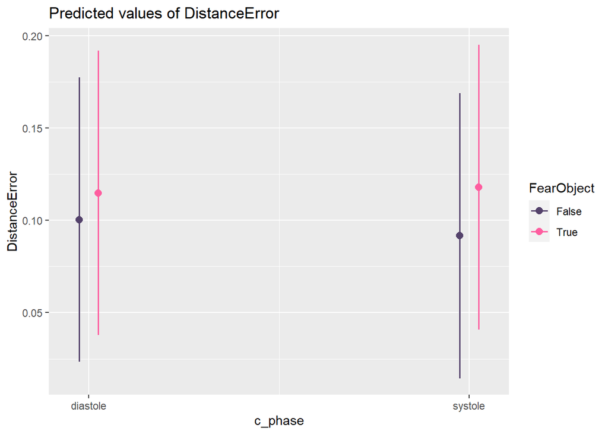

```r
# plot model
plot_model(full_model, type = "int", mdrt.values = "meansd", colors = c(c_nonthreat, c_threat))
```

```r
# compare models
lrtest(null_model, full_model)
```

```
## Likelihood ratio test
##
## Model 1: DistanceError ~ 1 + (1 + RealDistance | ID)
## Model 2: DistanceError ~ c_phase * FearObject + (1 + RealDistance | ID)
##   #Df LogLik Df  Chisq Pr(>Chisq)
## 1   5 -12883
## 2   8 -12888  3 9.9591    0.01892 *
## ---
## Signif. codes:  0 '***' 0.001 '**' 0.01 '*' 0.05 '.' 0.1 ' ' 1
```

*Bayes factors*

```r
# 4.3. Bayes factor analysis (comparisons of interest)

## Threatening animals
d <- data[data$FearObject == "True",]
d <- d[d$c_phase == "systole" | d$c_phase == "diastole", ]

# transform data
d <- d %>%
  dplyr::group_by(ID) %>%
  dplyr::summarize(m_systole  = mean(DistanceError[c_phase == "systole"]),
            m_diastole = mean(DistanceError[c_phase == "diastole"]))

# t-test (comparison of interest)
shapiro.test(d$m_systole)
```

```
##
##  Shapiro-Wilk normality test
##
## data:  d$m_systole
## W = 0.95912, p-value = 0.1465
```

```r
shapiro.test(d$m_diastole)
```

```
##
##  Shapiro-Wilk normality test
##
## data:  d$m_diastole
## W = 0.96168, p-value = 0.1801
```

```r
t.test(d$m_systole, d$m_diastole, paired = T)
```

```
##
##  Paired t-test
##
## data:  d$m_systole and d$m_diastole
## t = 0.4956, df = 40, p-value = 0.6229
## alternative hypothesis: true difference in means is not equal to 0
## 95 percent confidence interval:
##  -1.362676  2.248098
## sample estimates:
## mean of the differences
##               0.4427107
```

```r
# Bayes factor (comparison of interest + robustness check)
ttestBF(d$m_systole, d$m_diastole, paired = T)
```

```
## Bayes factor analysis
## --------------
## [1] Alt., r=0.707 : 0.1893011 ±0.05%
##
## Against denominator:
##   Null, mu = 0
## ---
## Bayes factor type: BFoneSample, JZS
```

```r
ttestBF(d$m_systole, d$m_diastole, paired = T, r = 1)
```

```
## Bayes factor analysis
## --------------
## [1] Alt., r=1 : 0.1372946 ±0.11%
##
## Against denominator:
##   Null, mu = 0
## ---
## Bayes factor type: BFoneSample, JZS
```

```r
ttestBF(d$m_systole, d$m_diastole, paired = T, r = 0.354)
```

```
## Bayes factor analysis
## --------------
## [1] Alt., r=0.354 : 0.3370599 ±0.01%
##
## Against denominator:
##   Null, mu = 0
## ---
## Bayes factor type: BFoneSample, JZS
```

```r
## Non-threatening animals
d <- data[data$FearObject == "False",]
d <- d[d$c_phase == "systole" | d$c_phase == "diastole", ]

# transform data
d <- d %>%
  dplyr::group_by(ID) %>%
  dplyr::summarize(
    m_systole = mean(DistanceError[c_phase == "systole"]),
    m_diastole = mean(DistanceError[c_phase == "diastole"])
  )

# t-test (comparison of interest)
shapiro.test(d$m_systole)
```

```
##
##  Shapiro-Wilk normality test
##
## data:  d$m_systole
## W = 0.95547, p-value = 0.1091
```

```r
shapiro.test(d$m_diastole)
```

```
##
##  Shapiro-Wilk normality test
##
## data:  d$m_diastole
## W = 0.95174, p-value = 0.08055
```

```r
t.test(d$m_systole, d$m_diastole, paired = T)
```

```
##
##  Paired t-test
##
## data:  d$m_systole and d$m_diastole
## t = -0.97655, df = 40, p-value = 0.3347
## alternative hypothesis: true difference in means is not equal to 0
## 95 percent confidence interval:
##  -2.506872  0.873517
## sample estimates:
## mean of the differences
##              -0.8166775
```

```r
# Bayes factor (comparison of interest + robustness check)
ttestBF(d$m_systole, d$m_diastole, paired = T)
```

```
## Bayes factor analysis
## --------------
## [1] Alt., r=0.707 : 0.2630926 ±0.05%
##
## Against denominator:
##   Null, mu = 0
## ---
## Bayes factor type: BFoneSample, JZS
```

```r
ttestBF(d$m_systole, d$m_diastole, paired = T, r = 1)
```

```
## Bayes factor analysis
## --------------
## [1] Alt., r=1 : 0.1932502 ±0.09%
##
## Against denominator:
##   Null, mu = 0
## ---
## Bayes factor type: BFoneSample, JZS
```

```r
ttestBF(d$m_systole, d$m_diastole, paired = T, r = 0.354)
```

```
## Bayes factor analysis
## --------------
## [1] Alt., r=0.354 : 0.4465132 ±0.01%
##
## Against denominator:
##   Null, mu = 0
## ---
## Bayes factor type: BFoneSample, JZS
```

*Binary analysis: Plots*

```r
# 4.4. Vizualize the results

# Threatening
d <- data[data$FearObject == "True",]
d <- d[d$c_phase == "systole" | d$c_phase == "diastole", ]

# transform data
d <- d %>%
  dplyr::group_by(ID) %>%
  dplyr::summarize(
    m_systole = mean(DistanceError[c_phase == "systole"]),
    m_diastole = mean(DistanceError[c_phase == "diastole"]),
    m_systole_ang = mean(AngularErrorDeg[c_phase == "systole"]),
    m_diastole_ang = mean(AngularErrorDeg[c_phase == "diastole"])
  )

# t-test (comparison of interest)
shapiro.test(d$m_systole)
```

```
##
##  Shapiro-Wilk normality test
##
## data:  d$m_systole
## W = 0.95912, p-value = 0.1465
```

```r
shapiro.test(d$m_diastole)
```

```
##
##  Shapiro-Wilk normality test
##
## data:  d$m_diastole
## W = 0.96168, p-value = 0.1801
```

```r
shapiro.test(d$m_systole_ang)
```

```
##
##  Shapiro-Wilk normality test
##
## data:  d$m_systole_ang
## W = 0.97658, p-value = 0.5486
```

```r
shapiro.test(d$m_diastole_ang)
```

```
##
##  Shapiro-Wilk normality test
##
## data:  d$m_diastole_ang
## W = 0.97837, p-value = 0.6143
```

```r
t.test(d$m_systole, d$m_diastole, paired = T)
```

```
##
##  Paired t-test
##
## data:  d$m_systole and d$m_diastole
## t = 0.4956, df = 40, p-value = 0.6229
## alternative hypothesis: true difference in means is not equal to 0
## 95 percent confidence interval:
##  -1.362676  2.248098
## sample estimates:
## mean of the differences
##               0.4427107
```

```r
t.test(d$m_systole_ang, d$m_diastole_ang, paired = TRUE)
```

```
##
##  Paired t-test
##
## data:  d$m_systole_ang and d$m_diastole_ang
## t = 0.90168, df = 40, p-value = 0.3726
## alternative hypothesis: true difference in means is not equal to 0
## 95 percent confidence interval:
##  -0.05576513  0.14560399
## sample estimates:
## mean of the differences
##              0.04491943
```

```r
d2 <- d
d2$diff <- d$m_diastole - d$m_systole
#hist(d2$diff, breaks = 20)
length(d2$diff[d2$diff < 0]) # closer at diastole
```

```
## [1] 23
```

```r
d <- gather(d, phase, distance_error, m_systole:m_diastole)
d$phase_f[d$phase == "m_systole"] <- 1
```

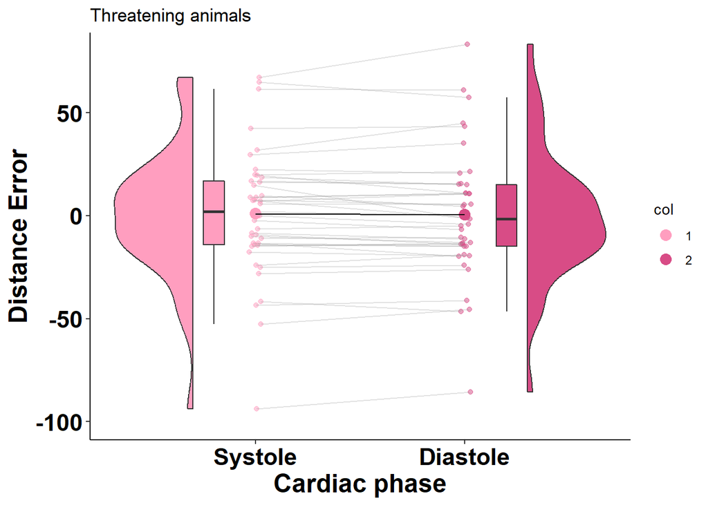

```r
d$phase_f[d$phase == "m_diastole"] <- 2
d$pos <- jitter(d$phase_f, amount=.03)

# threatening
c_threat_sys <- lighten(c_threat, amount = 0.35)   #  "#6c030f"
c_threat_dias <- darken(c_threat, amount = 0.15)  # "#af7d81"

f1 <- ggplot(data = d, aes(y = distance_error)) +

  geom_point(data = d %>% filter(phase_f =="1"), aes(x = pos), color = c_threat_sys, size = 1.5,
             alpha = .5) +
  geom_point(data = d %>% filter(phase_f =="2"), aes(x = pos), color = c_threat_dias, size = 1.5,
             alpha = .5) +
  geom_line(aes(x = pos, group = ID), color = 'gray60', alpha = .3) +

  geom_half_boxplot(
    data = d %>% filter(phase_f=="1"), aes(x=phase_f, y = distance_error), position = position_nudge(x = -.25),
    side = "r",outlier.shape = NA, center = TRUE, errorbar.draw = FALSE, width = .2,
    fill = c_threat_sys) +

  geom_half_boxplot(
    data = d %>% filter(phase_f=="2"), aes(x=phase_f, y = distance_error), position = position_nudge(x = .15),
    side = "r",outlier.shape = NA, center = TRUE, errorbar.draw = FALSE, width = .2,
    fill = c_threat_dias) +

  geom_half_violin(
    data = d %>% filter(phase_f=="1"),aes(x = phase_f, y = distance_error), position = position_nudge(x = -.3),
    side = "l", fill = c_threat_sys) +

  geom_half_violin(
    data = d %>% filter(phase_f=="2"),aes(x = phase_f, y = distance_error), position = position_nudge(x= .3),
    side = "r", fill = c_threat_dias) +

  geom_point(data = d %>%
              group_by(phase_f) %>%
              dplyr::summarize(gm_DistErr = mean(distance_error)) %>%
              mutate(col = factor(phase_f)),
              #mutate(loc = if_else(c_phase == "systole", 1, 2)),
            aes(x = phase_f, y = gm_DistErr, color = col),
            position = position_nudge(x = -.0),
            size = 5.5,
            shape = 20) +

  geom_line(data = d %>%
              group_by(phase_f) %>%
              dplyr::summarize(gm_DistErr = mean(distance_error)),
              #mutate(loc = if_else(c_phase == "systole", 1, 2)),
            aes(x = phase_f, y = gm_DistErr)) +

  #Define additional settings
  scale_x_continuous(breaks=c(1,2), labels=c("Systole", "Diastole")) +
  scale_color_manual(values = c(c_threat_sys, c_threat_dias)) +

  #Define additional settings
  scale_x_continuous(breaks=c(1,2), labels=c("Systole", "Diastole")) +
  xlab("Cardiac phase") + ylab("Distance Error") +
  ggtitle('Threatening animals') +
  theme_classic()+
  coord_cartesian(ylim=c(-100, 80)) +
   theme(panel.grid.major = element_blank(), panel.grid.minor = element_blank(),panel.background = element_blank(), axis.line = element_line(colour = "black"), axis.title = element_text(face="bold",size=18, colour = "black"), axis.text = element_text(face="bold",size=17, colour = "black"))
f1 # export size: 5 x 5
```

```r
# save to disc:
fpath_figs <- file.path(VRCC_dir, 'Code', 'Analyses', 'VRTask', 'Figures')
fname <- file.path(fpath_figs, 'VRCC_DistErr_BoxViolin_CardiacPhase_Threat.pdf')
pdf(fname)
f1
dev.off()
```

```r
### Non_threatening
c_nonthreat_sys <- lighten(c_nonthreat, amount = 0.35)   #  "#6c030f"   # darken(rgb(10/255, 80/255, 200/255),0.55)
c_nonthreat_dias <- darken(c_nonthreat, amount = 0.15)  # "#9590a8"

d <- data[data$FearObject == "False",]
d <- d[d$c_phase == "systole" | d$c_phase == "diastole", ]

d <- d %>%
  dplyr::group_by(ID) %>%
  dplyr::summarize(m_systole = mean(DistanceError[c_phase == "systole"]),
            m_diastole = mean(DistanceError[c_phase == "diastole"]))


d2 <- d
d2$diff <- d$m_diastole - d$m_systole
#hist(d2$diff, breaks = 20)
length(d2$diff[d2$diff < 0])
```

```
## [1] 15
```

```r
d <- gather(d, phase, distance_error, m_systole:m_diastole)
d$phase_f[d$phase == "m_systole"] <- 1
```

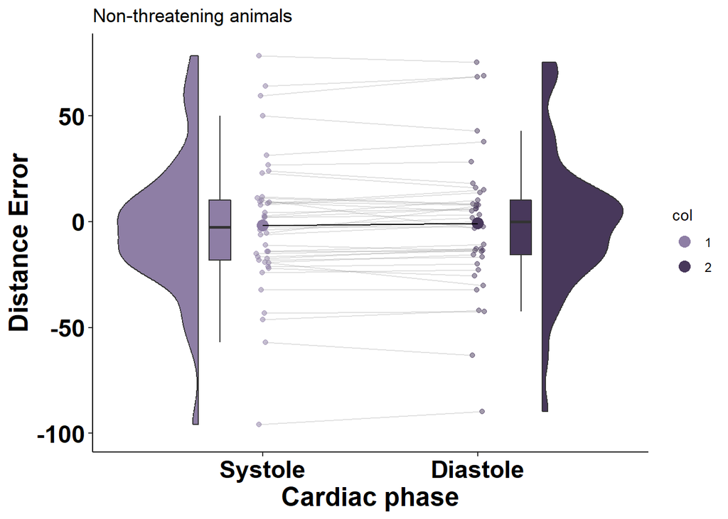

```r
d$phase_f[d$phase == "m_diastole"] <- 2
d$pos <- jitter(d$phase_f, amount=.03)

f2 <- ggplot(data = d, aes(y = distance_error)) +

  #Add geom_() objects
  geom_point(data = d %>% filter(phase_f =="1"), aes(x = pos), color = c_nonthreat_sys, size = 1.5,
             alpha = .5) +
  geom_point(data = d %>% filter(phase_f =="2"), aes(x = pos), color = c_nonthreat_dias, size = 1.5,
             alpha = .5) +
  geom_line(aes(x = pos, group = ID), color = 'gray60', alpha = .3) +

  geom_half_boxplot(
    data = d %>% filter(phase_f=="1"), aes(x=phase_f, y = distance_error), position = position_nudge(x = -.25),
    side = "r",outlier.shape = NA, center = TRUE, errorbar.draw = FALSE, width = .2,
    fill = c_nonthreat_sys) +

  geom_half_boxplot(
    data = d %>% filter(phase_f=="2"), aes(x=phase_f, y = distance_error), position = position_nudge(x = .15),
    side = "r",outlier.shape = NA, center = TRUE, errorbar.draw = FALSE, width = .2,
    fill = c_nonthreat_dias) +

  geom_half_violin(
    data = d %>% filter(phase_f=="1"),aes(x = phase_f, y = distance_error), position = position_nudge(x = -.3),
    side = "l", fill = c_nonthreat_sys) +

  geom_half_violin(
    data = d %>% filter(phase_f=="2"),aes(x = phase_f, y = distance_error), position = position_nudge(x= .3),
    side = "r",fill = c_nonthreat_dias) +

  geom_point(data = d %>%
              group_by(phase_f) %>%
              dplyr::summarize(gm_DistErr = mean(distance_error)) %>%
              mutate(col = factor(phase_f)),
              #mutate(loc = if_else(c_phase == "systole", 1, 2)),
            aes(x = phase_f, y = gm_DistErr, color = col),
            position = position_nudge(x = -.0),
            size = 5.5,
            shape = 20) +

  geom_line(data = d %>%
              group_by(phase_f) %>%
              dplyr::summarize(gm_DistErr = mean(distance_error)),
              #mutate(loc = if_else(c_phase == "systole", 1, 2)),
            aes(x = phase_f, y = gm_DistErr)) +

  #Define additional settings
  scale_x_continuous(breaks=c(1,2), labels=c("Systole", "Diastole")) +
  scale_color_manual(values = c(c_nonthreat_sys, c_nonthreat_dias)) +
  xlab("Cardiac phase") + ylab("Distance Error") +
  ggtitle('Non-threatening animals') +
  theme_classic()+
  coord_cartesian(ylim=c(-100, 80)) +
   theme(panel.grid.major = element_blank(),
         panel.grid.minor = element_blank(),
         panel.background = element_blank(),
         axis.line = element_line(colour = "black"),
         axis.title = element_text(face="bold",
                                   size=18,
                                   colour = "black"),
         axis.text = element_text(face="bold",size=17, colour = "black"))
f2 # export size: 5 x 5
```

```r
# save to disc:
fpath_figs <- file.path(VRCC_dir, 'Code', 'Analyses', 'VRTask', 'Figures')
fname <- file.path(fpath_figs, 'VRCC_DistErr_BoxViolin_CardiacPhase_NonThreat.pdf')
pdf(fname)
f2
dev.off()
```

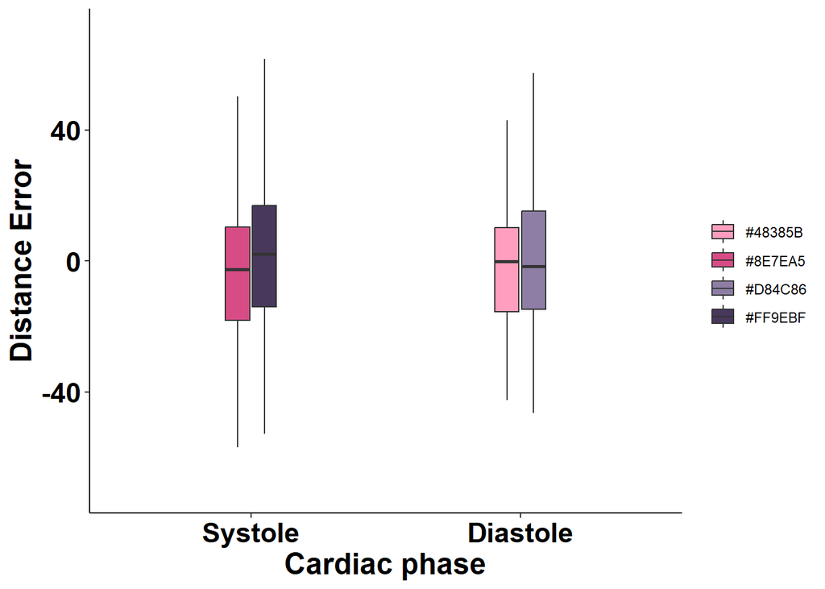

```r
# ANOVA plot:

d <- data %>%
  filter(c_phase == "systole" | c_phase == "diastole") %>%
  group_by(ID, c_phase, FearObject) %>%
  dplyr::summarise(m_DistErr = mean(DistanceError)) %>%
  mutate(c_phase = factor(c_phase,
                          levels = c("systole", "diastole"),
                          labels = c("Systole", "Diastole")),
         FearObject = factor(FearObject,
                             levels = c( "True" , "False"),
                             labels = c("Threatening", "Non-threatening")),
         Color = if_else(FearObject == "Threatening",
                         if_else(c_phase == "Systole",
                                 c_threat_sys,
                                 c_threat_dias),
                         if_else(c_phase == "Systole",
                                 c_nonthreat_sys,
                                 c_nonthreat_dias)))
f3 <- ggplot(data = d, aes(x = c_phase, y = m_DistErr, fill = Color)) +
  geom_boxplot(aes(),
               outlier.shape = NA,
               center = TRUE, errorbar.draw = FALSE, width = .2) +
  xlab("Cardiac phase") + ylab("Distance Error") +
  theme_classic()+
  scale_fill_manual(values = c(c_threat_sys, c_threat_dias, c_nonthreat_sys, c_nonthreat_dias),
                    name="") +
  coord_cartesian(ylim=c(-70, 70)) +
   theme(panel.grid.major = element_blank(),
         panel.grid.minor = element_blank(),
         panel.background = element_blank(),
         axis.line = element_line(colour = "black"),
         axis.title = element_text(face="bold",size=18, colour = "black"),
         axis.text = element_text(face="bold",size=17, colour = "black"))
f3
```

```r
# save to disc:
fpath_figs <- file.path(VRCC_dir, 'Code', 'Analyses', 'VRTask', 'Figures')
fname <- file.path(fpath_figs, 'VRCC_DistErr_BoxPlot_ANOVA.pdf')
pdf(fname)
f3
dev.off()
```

**Circular analysis (pre-registered): Mixed Model**

```r
# 4.5 Run preregistered analysis (circular approach)

# get circular components
rel_pos_circular <- get_circular_components(data$relPosRRrad, 2 * pi)

# add them to data
data$relPosRRradCircCos <- rel_pos_circular$cos_component
data$relPosRRradCircSin <- rel_pos_circular$sin_component

d <- data %>%
  mutate(RealDistance = RealDistance * 0.01,
         DistanceError = DistanceError * 0.01)

# null model
null_model <- lmer(DistanceError ~ 1 + (1 + RealDistance|ID), data = d, REML = FALSE)
summary(null_model)
```

```
## Linear mixed model fit by maximum likelihood . t-tests use Satterthwaite's
##   method [lmerModLmerTest]
## Formula: DistanceError ~ 1 + (1 + RealDistance | ID)
##    Data: d
##
##      AIC      BIC   logLik deviance df.resid
##  31894.4  31935.8 -15942.2  31884.4    28928
##
## Scaled residuals:
##     Min      1Q  Median      3Q     Max
## -7.2439 -0.5770 -0.0303  0.5475 15.2694
##
## Random effects:
##  Groups   Name         Variance Std.Dev. Corr
##  ID       (Intercept)  0.08377  0.2894
##           RealDistance 0.01149  0.1072   -0.55
##  Residual              0.17386  0.4170
## Number of obs: 28933, groups:  ID, 41
##
## Fixed effects:
##             Estimate Std. Error       df t value Pr(>|t|)
## (Intercept)  0.10518    0.03814 41.00885   2.758  0.00865 **
## ---
## Signif. codes:  0 '***' 0.001 '**' 0.01 '*' 0.05 '.' 0.1 ' ' 1
```

```r
# full model
full_model <- lmer(DistanceError ~ relPosRRradCircCos * FearObject + relPosRRradCircSin * FearObject + (1 + RealDistance|ID), data = d, REML = FALSE)
summary(full_model)
```

```
## Linear mixed model fit by maximum likelihood . t-tests use Satterthwaite's
##   method [lmerModLmerTest]
## Formula:
## DistanceError ~ relPosRRradCircCos * FearObject + relPosRRradCircSin *
##     FearObject + (1 + RealDistance | ID)
##    Data: d
##
##      AIC      BIC   logLik deviance df.resid
##  31883.7  31966.4 -15931.8  31863.7    28923
##
## Scaled residuals:
##     Min      1Q  Median      3Q     Max
## -7.2647 -0.5788 -0.0285  0.5466 15.2575
##
## Random effects:
##  Groups   Name         Variance Std.Dev. Corr
##  ID       (Intercept)  0.08357  0.2891
##           RealDistance 0.01149  0.1072   -0.55
##  Residual              0.17373  0.4168
## Number of obs: 28933, groups:  ID, 41
##
## Fixed effects:
##                                     Estimate Std. Error         df t value
## (Intercept)                        9.516e-02  3.818e-02  4.136e+01   2.492
## relPosRRradCircCos                 5.416e-03  4.903e-03  2.885e+04   1.105
## FearObjectTrue                     2.024e-02  4.904e-03  2.885e+04   4.128
## relPosRRradCircSin                -7.129e-03  4.912e-03  2.885e+04  -1.451
## relPosRRradCircCos:FearObjectTrue -6.526e-03  6.935e-03  2.885e+04  -0.941
## FearObjectTrue:relPosRRradCircSin  9.916e-03  6.947e-03  2.885e+04   1.427
##                                   Pr(>|t|)
## (Intercept)                         0.0168 *
## relPosRRradCircCos                  0.2693
## FearObjectTrue                    3.68e-05 ***
## relPosRRradCircSin                  0.1467
## relPosRRradCircCos:FearObjectTrue   0.3467
## FearObjectTrue:relPosRRradCircSin   0.1535
## ---
## Signif. codes:  0 '***' 0.001 '**' 0.01 '*' 0.05 '.' 0.1 ' ' 1
##
## Correlation of Fixed Effects:
##             (Intr) rlPRRCC FrObjT rPRRCS rPRRCC:
## rlPsRRrdCrC -0.001
## FearObjctTr -0.064  0.000
## rlPsRRrdCrS -0.001 -0.006   0.005
## rlPRRCC:FOT  0.000 -0.707  -0.004  0.004
## FrObT:PRRCS  0.000  0.005  -0.005 -0.707 -0.004
```

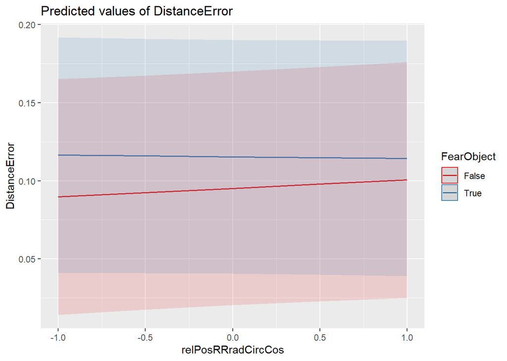

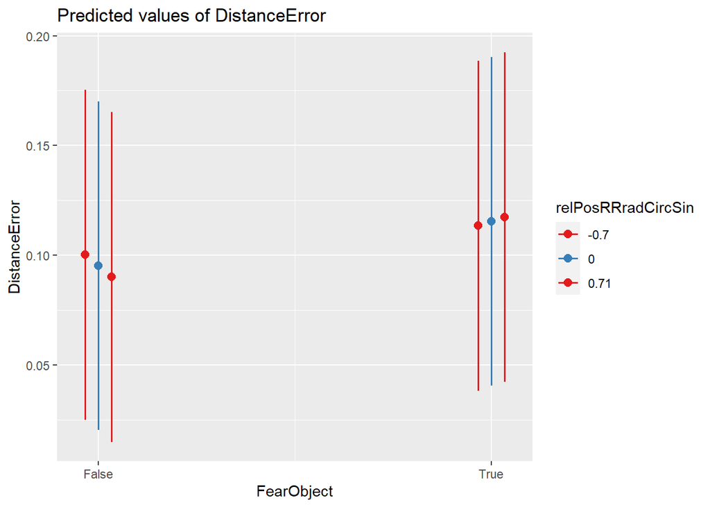

```r
plot_model(full_model, type = "int", mdrt.values = "meansd")
```

```r
get_r2_mlm(full_model)
```

```
## Variance explained by the model (conditional Nakagawa's R2):  0.3251218
## Variance explained by fixed effects (marginal Nakagawa's R2):  0.0004852712
```

```r
# compare models
lrtest(null_model, full_model)
```

```
## Likelihood ratio test
##
## Model 1: DistanceError ~ 1 + (1 + RealDistance | ID)
## Model 2: DistanceError ~ relPosRRradCircCos * FearObject + relPosRRradCircSin *
##     FearObject + (1 + RealDistance | ID)
##   #Df LogLik Df  Chisq Pr(>Chisq)
## 1   5 -15942
## 2  10 -15932  5 20.765  0.0008973 ***
## ---
## Signif. codes:  0 '***' 0.001 '**' 0.01 '*' 0.05 '.' 0.1 ' ' 1
```

```r
comparison <- anova(null_model, full_model)
print(comparison)
```

```
## Data: d
## Models:
## null_model: DistanceError ~ 1 + (1 + RealDistance | ID)
## full_model: DistanceError ~ relPosRRradCircCos * FearObject + relPosRRradCircSin * FearObject + (1 + RealDistance | ID)
##            npar   AIC   BIC logLik deviance  Chisq Df Pr(>Chisq)
## null_model    5 31894 31936 -15942    31884
## full_model   10 31884 31966 -15932    31864 20.765  5  0.0008973 ***
## ---
## Signif. codes:  0 '***' 0.001 '**' 0.01 '*' 0.05 '.' 0.1 ' ' 1
```

```r
# for the GAM-based circular graphs see the additional separate code in Python.
```

**5. Comparison of distance error between cardiac phases (individual animals)**

```r
###5.1. Item-by-item comparisons

# prepare data
d <- data[data$c_phase == "systole" | data$c_phase == "diastole", ]

d <- d %>%
  dplyr::group_by(ID, Stimulus, c_phase) %>%
  dplyr::summarize(distance_error = mean(DistanceError))
d <- spread(d, key = Stimulus, value = distance_error)

d <- pivot_wider(d, names_from = c(c_phase), values_from = c(Scorpio, Crocodile, FinalSnake, FinalWolf, Deer, Pig, Turtle, Rabbit))


## Threatening

# Scorpio
shapiro.test(d$Scorpio_diastole)
```

```
##
##  Shapiro-Wilk normality test
##
## data:  d$Scorpio_diastole
## W = 0.96736, p-value = 0.2819
```

```r
shapiro.test(d$Scorpio_systole)
```

```
##
##  Shapiro-Wilk normality test
##
## data:  d$Scorpio_systole
## W = 0.96004, p-value = 0.1578
```

```r
t.test(d$Scorpio_systole, d$Scorpio_diastole, paired = T)
```

```
##
##  Paired t-test
##
## data:  d$Scorpio_systole and d$Scorpio_diastole
## t = 0.63097, df = 40, p-value = 0.5316
## alternative hypothesis: true difference in means is not equal to 0
## 95 percent confidence interval:
##  -1.953484  3.726863
## sample estimates:
## mean of the differences
##               0.8866893
```

```r
# Wolf
shapiro.test(d$FinalWolf_diastole)
```

```
##
##  Shapiro-Wilk normality test
##
## data:  d$FinalWolf_diastole
## W = 0.90775, p-value = 0.002831
```

```r
shapiro.test(d$FinalWolf_systole)
```

```
##
##  Shapiro-Wilk normality test
##
## data:  d$FinalWolf_systole
## W = 0.94075, p-value = 0.03334
```

```r
wilcox.test(d$FinalWolf_systole, d$FinalWolf_diastole, paired = T)
```

```
##
##  Wilcoxon signed rank exact test
##
## data:  d$FinalWolf_systole and d$FinalWolf_diastole
## V = 506, p-value = 0.3348
## alternative hypothesis: true location shift is not equal to 0
```

```r
# Snake
shapiro.test(d$FinalSnake_diastole)
```

```
##
##  Shapiro-Wilk normality test
##
## data:  d$FinalSnake_diastole
## W = 0.97353, p-value = 0.4461
```

```r
shapiro.test(d$FinalSnake_systole)
```

```
##
##  Shapiro-Wilk normality test
##
## data:  d$FinalSnake_systole
## W = 0.96349, p-value = 0.208
```

```r
t.test(d$FinalSnake_systole, d$FinalSnake_diastole, paired = T)
```

```
##
##  Paired t-test
##
## data:  d$FinalSnake_systole and d$FinalSnake_diastole
## t = -0.71488, df = 40, p-value = 0.4788
## alternative hypothesis: true difference in means is not equal to 0
## 95 percent confidence interval:
##  -4.466503  2.132399
## sample estimates:
## mean of the differences
##               -1.167052
```

```r
# Crocodile
shapiro.test(d$Crocodile_diastole)
```

```
##
##  Shapiro-Wilk normality test
##
## data:  d$Crocodile_diastole
## W = 0.98008, p-value = 0.6785
```

```r
shapiro.test(d$Crocodile_systole)
```

```
##
##  Shapiro-Wilk normality test
##
## data:  d$Crocodile_systole
## W = 0.97531, p-value = 0.5046
```

```r
t.test(d$Crocodile_systole, d$Crocodile_diastole, paired = T)
```

```
##
##  Paired t-test
##
## data:  d$Crocodile_systole and d$Crocodile_diastole
## t = 0.048312, df = 40, p-value = 0.9617
## alternative hypothesis: true difference in means is not equal to 0
## 95 percent confidence interval:
##  -2.533711  2.657810
## sample estimates:
## mean of the differences
##              0.06204971
```

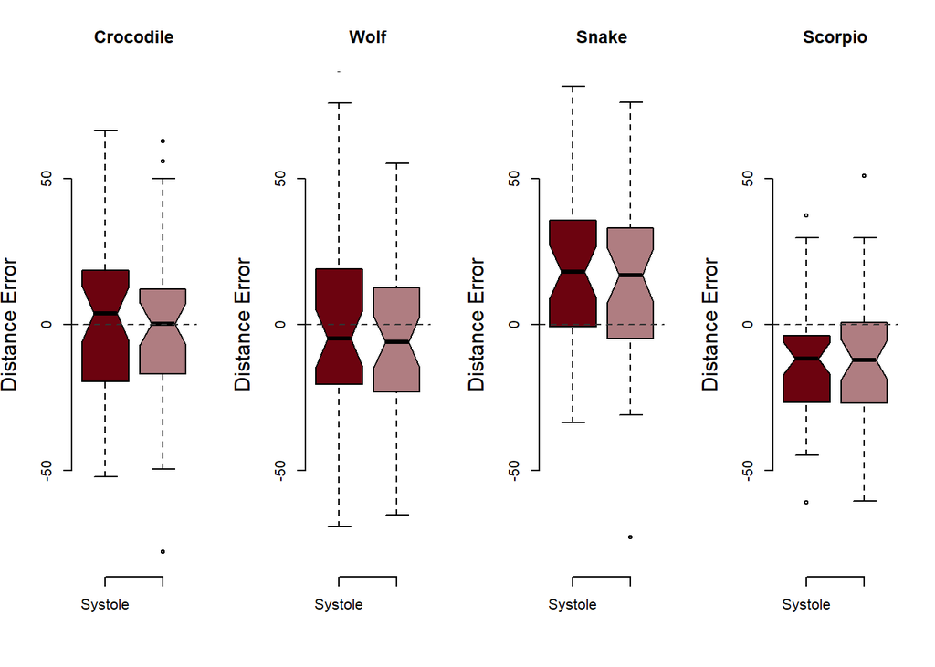

```r
# prepare graphics
par(mfrow=c(1,4))
c_threat_sys <- "#6c030f"
c_threat_dias <- "#af7d81"

boxplot(d$Crocodile_systole, d$Crocodile_diastole, col = c(c_threat_sys, c_threat_dias), names = c("Systole", "Diastole"), frame = FALSE, notch = TRUE, ylab = "Distance Error", cex.lab = 1.4, cex.axis = 1, ylim = c(-80,80), main = "Crocodile")
abline(h=0, col="gray20", lwd = 1.3, lty = 2)


boxplot(d$FinalWolf_systole, d$FinalWolf_diastole, col = c(c_threat_sys, c_threat_dias), names = c("Systole", "Diastole"), frame = FALSE, notch = TRUE, ylab = "Distance Error", cex.lab = 1.4, cex.axis = 1, ylim = c(-80,80), main = "Wolf")
abline(h=0, col="gray20", lwd = 1.3, lty = 2)


boxplot(d$FinalSnake_systole, d$FinalSnake_diastole, col = c(c_threat_sys, c_threat_dias), names = c("Systole", "Diastole"), frame = FALSE, notch = TRUE, ylab = "Distance Error", cex.lab = 1.4, cex.axis = 1, ylim = c(-80,80), main = "Snake")
abline(h=0, col="gray20", lwd = 1.3, lty = 2)


boxplot(d$Scorpio_systole, d$Scorpio_diastole, col = c(c_threat_sys, c_threat_dias), names = c("Systole", "Diastole"), frame = FALSE, notch = TRUE, ylab = "Distance Error", cex.lab = 1.4, cex.axis = 1, ylim = c(-80,80), main = "Scorpio")
abline(h=0, col="gray20", lwd = 1.3, lty = 2)
```

```r
# export 3 x 7.5 cm


## Non-threatening

# Deer
shapiro.test(d$Deer_diastole)
```

```
##
##  Shapiro-Wilk normality test
##
## data:  d$Deer_diastole
## W = 0.90842, p-value = 0.002968
```

```r
shapiro.test(d$Deer_systole)
```

```
##
##  Shapiro-Wilk normality test
##
## data:  d$Deer_systole
## W = 0.90112, p-value = 0.001789
```

```r
wilcox.test(d$Deer_systole, d$Deer_diastole, paired = T)
```

```
##
##  Wilcoxon signed rank exact test
##
## data:  d$Deer_systole and d$Deer_diastole
## V = 365, p-value = 0.4036
## alternative hypothesis: true location shift is not equal to 0
```

```r
# Turtle
shapiro.test(d$Turtle_diastole)
```

```
##
##  Shapiro-Wilk normality test
##
## data:  d$Turtle_diastole
## W = 0.96371, p-value = 0.2117
```

```r
shapiro.test(d$Turtle_systole)
```

```
##
##  Shapiro-Wilk normality test
##
## data:  d$Turtle_systole
## W = 0.95598, p-value = 0.1136
```

```r
t.test(d$Turtle_systole, d$Turtle_diastole, paired = T)
```

```
##
##  Paired t-test
##
## data:  d$Turtle_systole and d$Turtle_diastole
## t = 0.13527, df = 40, p-value = 0.8931
## alternative hypothesis: true difference in means is not equal to 0
## 95 percent confidence interval:
##  -3.133281  3.582793
## sample estimates:
## mean of the differences
##               0.2247562
```

```r
# Pig
shapiro.test(d$Pig_diastole)
```

```
##
##  Shapiro-Wilk normality test
##
## data:  d$Pig_diastole
## W = 0.97443, p-value = 0.475
```

```r
shapiro.test(d$Pig_systole)
```

```
##
##  Shapiro-Wilk normality test
##
## data:  d$Pig_systole
## W = 0.97301, p-value = 0.43
```

```r
t.test(d$Pig_systole, d$Pig_diastole, paired = T)
```

```
##
##  Paired t-test
##
## data:  d$Pig_systole and d$Pig_diastole
## t = -0.30332, df = 40, p-value = 0.7632
## alternative hypothesis: true difference in means is not equal to 0
## 95 percent confidence interval:
##  -3.389836  2.505141
## sample estimates:
## mean of the differences
##              -0.4423477
```

```r
# Rabbit
shapiro.test(d$Rabbit_diastole)
```

```
##
##  Shapiro-Wilk normality test
##
## data:  d$Rabbit_diastole
## W = 0.96634, p-value = 0.2604
```

```r
shapiro.test(d$Rabbit_systole)
```

```
##
##  Shapiro-Wilk normality test
##
## data:  d$Rabbit_systole
## W = 0.97491, p-value = 0.4911
```

```r
t.test(d$Rabbit_systole, d$Rabbit_diastole, paired = T)
```

```
##
##  Paired t-test
##
## data:  d$Rabbit_systole and d$Rabbit_diastole
## t = -0.76131, df = 40, p-value = 0.4509
## alternative hypothesis: true difference in means is not equal to 0
## 95 percent confidence interval:
##  -4.793359  2.170253
## sample estimates:
## mean of the differences
##               -1.311553
```

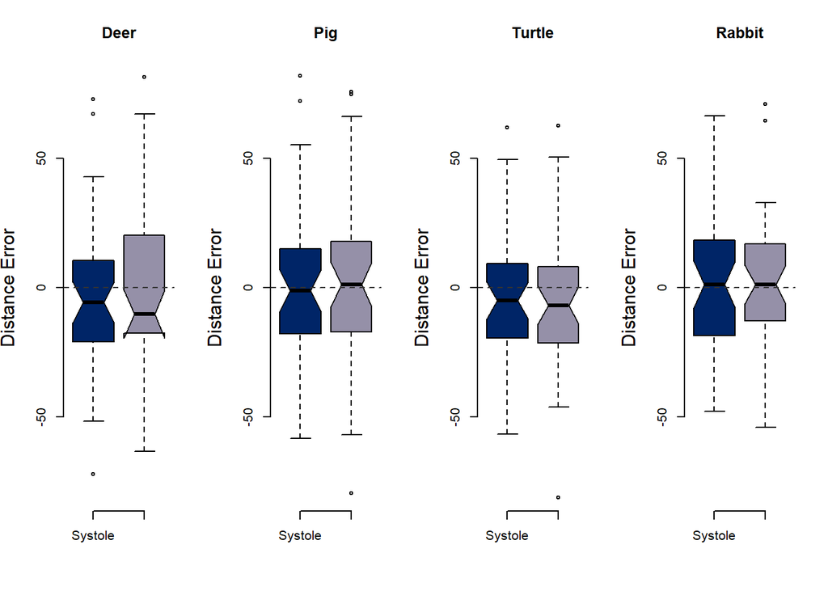

```r
# prepare graphics
par(mfrow=c(1,4))
c_nonthreat_sys <- darken(rgb(10/255, 80/255, 200/255),0.55)
c_nonthreat_dias <- "#9590a8"

boxplot(d$Deer_systole, d$Deer_diastole, col = c(c_nonthreat_sys, c_nonthreat_dias), names = c("Systole", "Diastole"), frame = FALSE, notch = TRUE, ylab = "Distance Error", cex.lab = 1.4, cex.axis = 1, ylim = c(-80,80), main = "Deer")
abline(h=0, col="gray20", lwd = 1.3, lty = 2)


boxplot(d$Pig_systole, d$Pig_diastole, col = c(c_nonthreat_sys, c_nonthreat_dias), names = c("Systole", "Diastole"), frame = FALSE, notch = TRUE, ylab = "Distance Error", cex.lab = 1.4, cex.axis = 1, ylim = c(-80,80), main = "Pig")
abline(h=0, col="gray20", lwd = 1.3, lty = 2)


boxplot(d$Turtle_systole, d$Turtle_diastole, col = c(c_nonthreat_sys, c_nonthreat_dias), names = c("Systole", "Diastole"), frame = FALSE, notch = TRUE, ylab = "Distance Error", cex.lab = 1.4, cex.axis = 1, ylim = c(-80,80), main = "Turtle")
abline(h=0, col="gray20", lwd = 1.3, lty = 2)


boxplot(d$Rabbit_systole, d$Rabbit_diastole, col = c(c_nonthreat_sys, c_nonthreat_dias), names = c("Systole", "Diastole"), frame = FALSE, notch = TRUE, ylab = "Distance Error", cex.lab = 1.4, cex.axis = 1, ylim = c(-80,80), main = "Rabbit")
abline(h=0, col="gray20", lwd = 1.3, lty = 2)
```

```r
# export 3 x 7.5 cm
```

**6. Distance errors as a function of true distance (individual animals)**

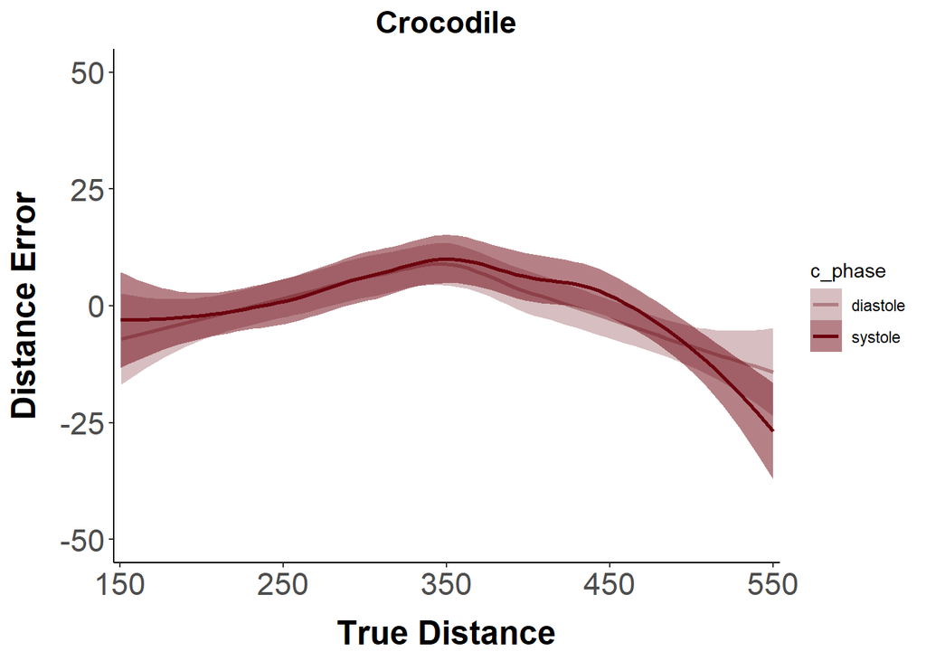

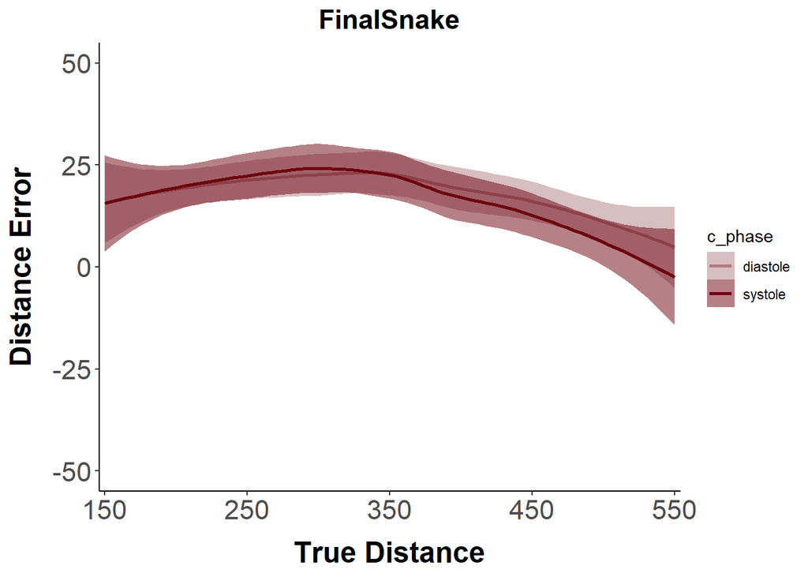

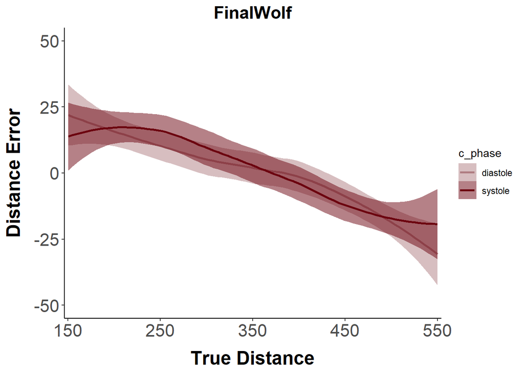

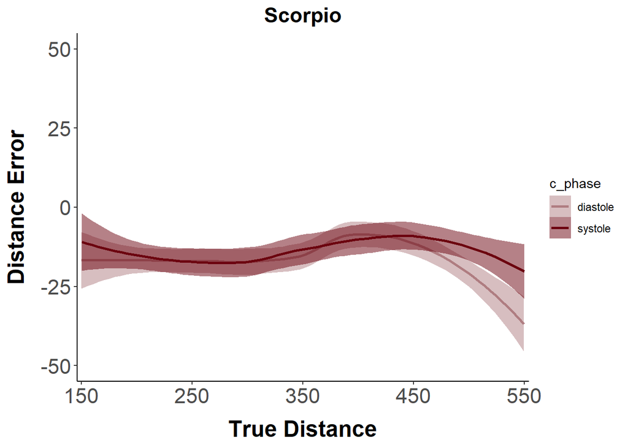

```r
## Threatening animals

# prepare data
d <- data[data$c_phase == "systole" | data$c_phase == "diastole", ]
d <- d[d$FearObject == "True",]

# prepare graphics
c_threat_sys <- "#6c030f"
c_threat_dias <- "#af7d81"
bold.text <- element_text(face = "bold", color = "black")

# plot the resuls for different animals
for (p in unique(d$Stimulus)) {

subdata <- d[d$Stimulus == p,]

Figure <- ggplot(data = subdata, aes(x = RealDistance, y = DistanceError, color = c_phase)) + geom_smooth(method = "loess", level=0.95, alpha = 0.5, aes(fill=c_phase)) +
  labs(y = "Distance Error", x = "True Distance") +
  ggtitle(p) + scale_color_manual(values = c('systole' = c_threat_sys, 'diastole' = c_threat_dias)) + scale_fill_manual(values = c('systole' = c_threat_sys, 'diastole' = c_threat_dias)) +
  theme_classic() +
  theme(plot.title = element_text(hjust = 0.5, face = "bold", size = 17), axis.text=element_text(size=17),  axis.title=element_text(size=18)) +
  scale_x_continuous(limits= c(min(data$RealDistance), max(data$RealDistance)), expand = c(0.01,0.01)) + coord_cartesian(ylim=c(-50, 50)) + theme(axis.title = bold.text, axis.title.y = element_text(margin = margin(t = 0, r = 10, b = 0, l = 0)), axis.title.x =   element_text(margin = margin(t = 10, r = 0, b = 0, l = 0)))

plot(Figure)
}
```

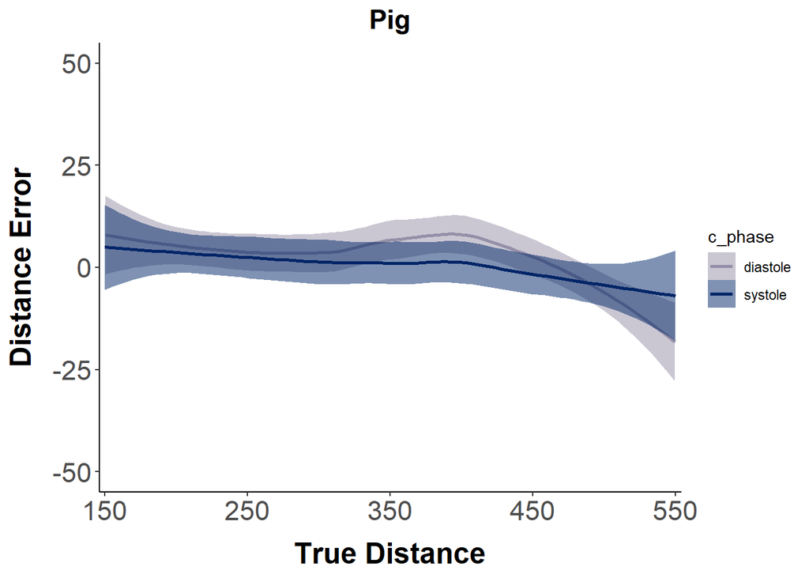

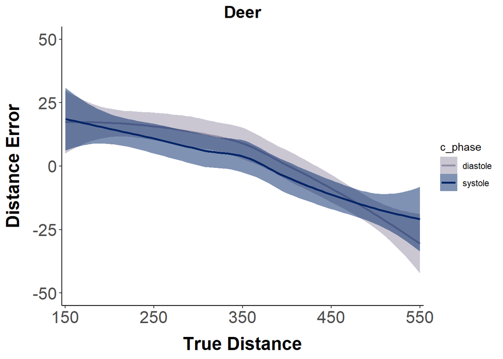

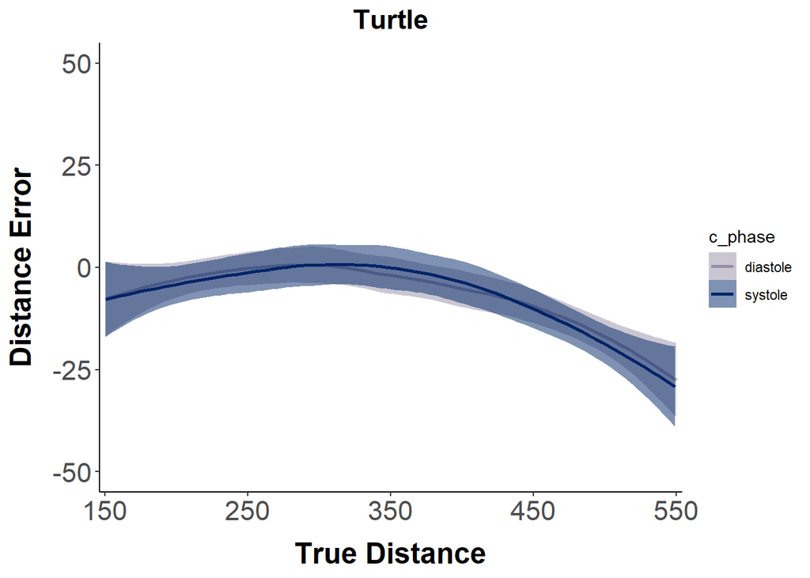

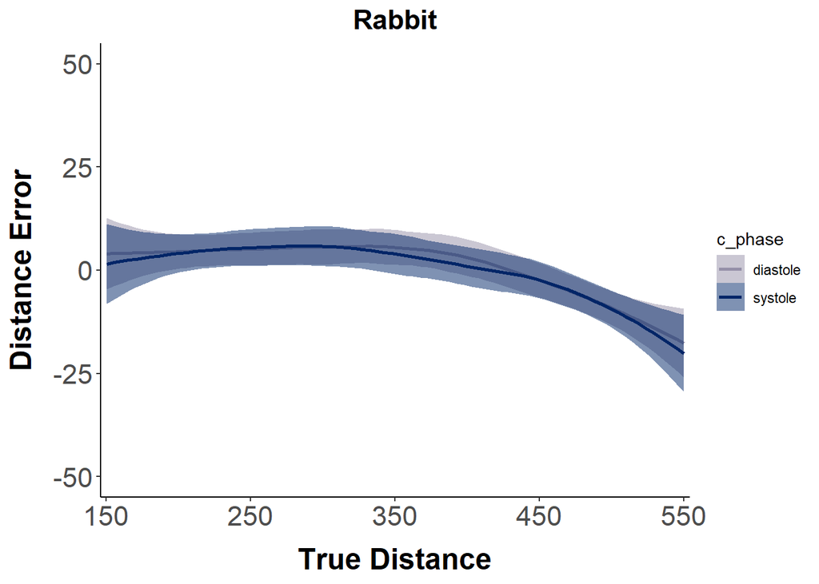

```r
## Non-threatening animals

# prepare data
d <- data[data$c_phase == "systole" | data$c_phase == "diastole", ]
d <- d[d$FearObject == "False",]

# prepare graphics
c_nonthreat_sys <- darken(rgb(10/255, 80/255, 200/255),0.55)
c_nonthreat_dias <- "#9590a8"

# plot the results for different animals
for (p in unique(d$Stimulus)) {

subdata <- d[d$Stimulus == p,]

Figure <- ggplot(data = subdata, aes(x = RealDistance, y = DistanceError, color = c_phase)) + geom_smooth(method = "loess", level=0.95, alpha = 0.5, aes(fill=c_phase)) +
  labs(y = "Distance Error", x = "True Distance") +
  ggtitle(p) + scale_color_manual(values = c('systole' = c_nonthreat_sys, 'diastole' = c_nonthreat_dias)) + scale_fill_manual(values = c('systole' = c_nonthreat_sys, 'diastole' = c_nonthreat_dias)) +
  theme_classic() +
  theme(plot.title = element_text(hjust = 0.5, face = "bold", size = 17), axis.text=element_text(size=17),  axis.title=element_text(size=18)) +
  scale_x_continuous(limits= c(min(data$RealDistance), max(data$RealDistance)), expand = c(0.01,0.01)) + coord_cartesian(ylim=c(-50, 50)) + theme(axis.title = bold.text, axis.title.y = element_text(margin = margin(t = 0, r = 10, b = 0, l = 0)), axis.title.x =   element_text(margin = margin(t = 10, r = 0, b = 0, l = 0)))

plot(Figure)
}
```

**7. Width of (distance & angular) error distributions as function of threat and cardiac phase**

```r
# model width of distance error distributions as function of threat and cardiac phase
aov_d <- data %>%
  filter(c_phase %in% c("diastole", "systole")) %>%
  group_by(ID, FearObject, c_phase) %>%
  dplyr::summarise(sd = sd(abs(DistanceError))) %>%
  ungroup()
cat("\n\n### ANOVA – sd DISTANCE ERROR:\n")
```

```
##
##
## ### ANOVA – sd DISTANCE ERROR:
```

```r
fit_all <- aov_ez(data = aov_d,
                  dv = "sd",
                  id = "ID",
                  within=c("c_phase", "FearObject"),
                  return = afex_options("return_aov"),
                  anova_table = list(),
                  fun_aggregate = mean)
fit_all
```

```
## Anova Table (Type 3 tests)
##
## Response: sd
##               Effect    df   MSE      F   ges p.value
## 1            c_phase 1, 40 11.27   0.00 <.001    .961
## 2         FearObject 1, 40 28.26 4.33 *  .005    .044
## 3 c_phase:FearObject 1, 40 11.05   0.22 <.001    .645
## ---
## Signif. codes:  0 '***' 0.001 '**' 0.01 '*' 0.05 '+' 0.1 ' ' 1
```

```r
summary(fit_all)
```

```
##
## Univariate Type III Repeated-Measures ANOVA Assuming Sphericity
##
##                    Sum Sq num Df Error SS den Df  F value Pr(>F)
## (Intercept)        156190      1  20980.4     40 297.7824 <2e-16 ***
## c_phase                 0      1    450.7     40   0.0024 0.9610
## FearObject            122      1   1130.5     40   4.3254 0.0440 *
## c_phase:FearObject      2      1    442.0     40   0.2156 0.6449
## ---
## Signif. codes:  0 '***' 0.001 '**' 0.01 '*' 0.05 '.' 0.1 ' ' 1
```

```r
print(aov_d %>%
        group_by(FearObject) %>%
        dplyr::summarise(mean_sd = mean(sd),
                         sd_sd = sd(sd)))
```

```
## # A tibble: 2 x 3
##   FearObject mean_sd sd_sd
##   <chr>        <dbl> <dbl>
## 1 False         30.0  11.7
## 2 True          31.7  12.2
```

```r
# model angular error as function of threat and cardiac phase
aov_d <- data %>%
  filter(c_phase %in% c("diastole", "systole")) %>%
  group_by(ID, FearObject, c_phase) %>%
  dplyr::summarise(m = mean(abs(AngularErrorDeg)),
                   sd = sd(AngularErrorDeg)) %>%
  ungroup()
cat("\n\n### ANOVA – mean ANG ERROR\n")
```

```
##
##
## ### ANOVA – mean ANG ERROR
```

```r
fit_all <- aov_ez(data = aov_d,
                  dv = "m",
                  id = "ID",
                  within=c("c_phase", "FearObject"),
                  return = afex_options("return_aov"),
                  anova_table = list(),
                  fun_aggregate = mean)
fit_all
```

```
## Anova Table (Type 3 tests)
##
## Response: m
##               Effect    df  MSE    F   ges p.value
## 1            c_phase 1, 40 0.02 0.01 <.001    .935
## 2         FearObject 1, 40 0.04 0.12 <.001    .726
## 3 c_phase:FearObject 1, 40 0.02 2.24  .002    .143
## ---
## Signif. codes:  0 '***' 0.001 '**' 0.01 '*' 0.05 '+' 0.1 ' ' 1
```

```r
summary(fit_all)
```

```
##
## Univariate Type III Repeated-Measures ANOVA Assuming Sphericity
##
##                    Sum Sq num Df Error SS den Df  F value Pr(>F)
## (Intercept)        495.01      1  21.7565     40 910.0971 <2e-16 ***
## c_phase              0.00      1   0.6902     40   0.0066 0.9355
## FearObject           0.01      1   1.7032     40   0.1247 0.7259
## c_phase:FearObject   0.04      1   0.7206     40   2.2356 0.1427
## ---
## Signif. codes:  0 '***' 0.001 '**' 0.01 '*' 0.05 '.' 0.1 ' ' 1
```

```r
cat("\n\n### ANOVA – sd ANG ERROR\n")
```

```
##
##
## ### ANOVA – sd ANG ERROR
```

```r
fit_all <- aov_ez(data = aov_d,
                  dv = "sd",
                  id = "ID",
                  within=c("c_phase", "FearObject"),
                  return = afex_options("return_aov"),
                  anova_table = list(),
                  fun_aggregate = mean)
fit_all
```

```
## Anova Table (Type 3 tests)
##
## Response: sd
##               Effect    df  MSE         F   ges p.value
## 1            c_phase 1, 40 0.05      0.24 <.001    .624
## 2         FearObject 1, 40 0.07 16.45 ***  .037   <.001
## 3 c_phase:FearObject 1, 40 0.05      0.34 <.001    .562
## ---
## Signif. codes:  0 '***' 0.001 '**' 0.01 '*' 0.05 '+' 0.1 ' ' 1
```

```r
summary(fit_all)
```

```
##
## Univariate Type III Repeated-Measures ANOVA Assuming Sphericity
##
##                    Sum Sq num Df Error SS den Df   F value    Pr(>F)
## (Intercept)        720.57      1  23.0404     40 1250.9642 < 2.2e-16 ***
## c_phase              0.01      1   2.1389     40    0.2444  0.623758
## FearObject           1.14      1   2.7696     40   16.4460  0.000225 ***
## c_phase:FearObject   0.02      1   1.8646     40    0.3416  0.562208
## ---
## Signif. codes:  0 '***' 0.001 '**' 0.01 '*' 0.05 '.' 0.1 ' ' 1
```

```r
print(aov_d %>%
        group_by(FearObject) %>%
        dplyr::summarise(grand_m = mean(m),
                         grand_sd = sd(m),
                         mean_sd = mean(sd),
                         sd_sd = sd(sd)))
```

```
## # A tibble: 2 x 5
##   FearObject grand_m grand_sd mean_sd sd_sd
##   <chr>        <dbl>    <dbl>   <dbl> <dbl>
## 1 False         1.73    0.429    2.01 0.406
## 2 True          1.74    0.352    2.18 0.451
```